# Sen’s Trend Estimator Report

**Dataset**: AMS variance.

**Sen’s Trend Estimator** is used to estimate the slope of a regression line. Unlike [Least Squares](https://en.wikipedia.org/wiki/Least_squares), Sen’s trend estimator uses a non-parametric approach which makes it robust to outliers.

After computing the regression line using Sen’s trend estimator, we use the **Runs Test** to determine whether the residuals from the regression are random. If the Runs test identifies a non-random pattern in the residuals, it is a strong indication that the non-stationarity in the data is non-linear.

- Null hypothesis: The residuals are distributed randomly.
- Alternative hypothesis: The residuals *are not* distributed randomly.

To compute Sen’s trend estimator we use the following procedure:

1. Iterate over all pairs of data points $(x_{i}, y_{i})$ and $(x_{j}, y_{j})$.
2. If $x_{i} \neq x_{j}$, compute the slope $(y_{j} - y_{i})/(x_{j} - x_{i})$ and add it to a list $S$.
3. Sen’s trend estimator $\hat{m}$ is the median of $S$.

After computing $\hat{m}$, we can estimate the $y$-intercept $b$ by the median of $y_{i} - \hat{m}x_{i}$ for all $i$.

Prior to applying the Runs test, the data is categorized based on whether it is above ($+$) or below ($-$) the median.

Then, we compute the number of contiguous blocks of $+$ or $-$ (or *runs*) in the data.

> **Example**: Suppose that after categorization, the sequence of data is as follows:

> $$+++--+++-+-$$

> This sequence has six runs with length $(3, 2, 3, 1,1, 1)$.

Let $R$ be the number of runs in $N$ data points (with category counts $N_{+}$ and $N_{-}$).

Then, $R$ is asymptotically normal with the following parameters:

$$\mathbb{E}[R] = \frac{2N_{+}N_{-}}{N} + 1, \quad
\text{Var}(R) = \frac{2N_{+}N_{-}(2N_{+}N_{-} - N)}{N^2(N - 1)}$$

For more information, see the [Wikipedia](https://en.wikipedia.org/wiki/Wald%E2%80%93Wolfowitz_runs_test) entry or the [R Documentation](https://search.r-project.org/CRAN/refmans/randtests/html/runs.test.html).

### Results

- Estimated trend: y = -0.009x + 71.66.
- The Runs test yielded a p-value of 0.358.
- At a significance level of 0.05, we fail to reject the null hypothesis.
- Therefore, there is evidence the residuals are random.

### Figure

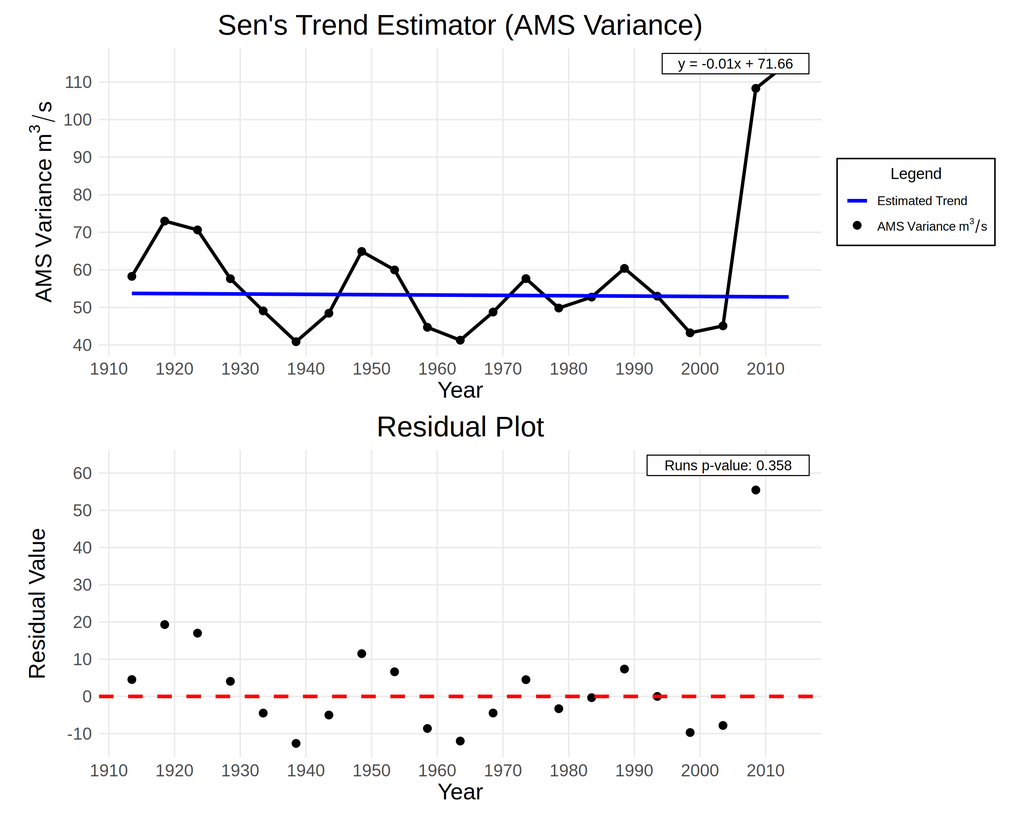

### Test Code

```r
library(randtests)

# Compute Sen's trend estimator for a dataframe
#  - data: A vector of AMS data or AMS variances with no NA values
#  - year: A numeric vector of years corresponding to data with no NA values
sens_estimator <- function(data, year, alpha = 0.05) {

    # Get the length of data for convenience
    n <- length(data)

    # Compute all pairwise slopes
    slopes <- c()
    for (i in 1:(n-1)) {
        for (j in (i+1):n) {
            slopes <- c(slopes, (data[j] - data[i]) / (year[j] - year[i]))
        }
    }

    # Get the estimate for the slope
    sens_slope <- median(slopes)

    # Get the estimate for the intercept
    intercepts <- data - (sens_slope * year)
    sens_intercept <- median(intercepts)

    # Compute the predicted AMS values and the residuals
    predicted_data <- sens_intercept + (sens_slope * year)
    residuals <- data - predicted_data

    # Check for randomness of the residuals using the Wald-Wolfowitz runs test
    # https://search.r-project.org/CRAN/refmans/randtests/html/runs.test.html
    results <- runs.test(residuals)
    p_value <- results$p.value

    # Determine whether we reject or fail to reject based on p_value and alpha
    reject <- (p_value <= alpha)

    # Print the results of Sen's trend estimator and the Runs test
    m <- sens_slope
    b <- sens_intercept

    part1 <- ifelse(reject, "reject", "fail to reject")
    part2 <- ifelse(reject, "are NOT random", "are random")

    lines <- c(
        "Estimated trend: y = {round(m, 3)}x + {round(b, 2)}.",
        "The Runs test yielded a p-value of {round(p_value, 3)}.",
        "At a significance level of {alpha}, we {part1} the null hypothesis.",
        "Therefore, there is evidence the residuals {part2}."
    )

    msg <- glue(paste0("\n - ", lines, collapse = ""))
    message(msg)

    # Return the results as a list
    mget(c("sens_slope", "sens_intercept", "residuals", "p_value", "reject", "msg"))

}
```

### Plotting Code

```r
library(ggplot2)
library(grid)
library(glue)

# Source the plot theme (path is relative to /source)
source("helpers/plot-theme.R")
source("helpers/plot-annotation.R")


# Plot the results of Sen's trend estimator
sens_plot <- function(df, results, name, show_trend) {

    # Load the results of the test into the environment
    m <- results$sens_slope
    b <- results$sens_intercept
    p <- results$p_value

    # Set labels and data based on the name
    if (name == "sens-variance") {
        data <- df$std
        ams_label <- expression(AMS ~ Variance ~ m^3/s)
        title <- "Sen's Trend Estimator (AMS Variance)"
    } else {
        data <- df$max
        ams_label <- expression(AMS ~ m^3/s)
        title <- "Sen's Trend Estimator (AMS Mean)"
    }

    # Generate dataframes for the trend estimate, data, and residuals
    df_line <- data.frame(x = df$year, y = m * (df$year) + b)
    df_data <- data.frame(x = df$year, y = data)
    df_residuals <- data.frame(x = df$year, y = results$residuals)

    # Generate the equation and runs test label
    eq_label <- glue("y = {round(m, 2)}x + {round(b, 2)}")
    runs_label <- glue("Runs p-value: {round(p, 3)}")

    # First subplot: Plot of Sen's trend estimator
    p1 <- ggplot(df_data, aes(x = x, y = y)) +
        geom_point(aes(color = "black"), size = 2.25) +
        (if (show_trend) geom_line(color = "black", linewidth = 1.1) else NULL) +
        geom_line(data = df_line, aes(x = x, y = y, color = "blue"), linewidth = 1.2) +
        labs(title = title, x = "Year", y = ams_label, color = "Legend") +
        scale_color_manual(
            values = c("blue" = "blue", "black" = "black"),
            breaks = c("blue", "black"),
            labels = c("Estimated Trend", ams_label),
        )

    # Add equation annotation
    p1 <- add_annotation(p1, eq_label)

    # First subplot: Plot of residuals
    p2 <- ggplot(df_residuals, aes(x = x, y = y)) +
        geom_point(color = "black", size = 2.25) +
        geom_hline(yintercept = 0, color = "red", linetype = "dashed", linewidth = 1.2) +
        labs(title = "Residual Plot", x = "Year", y = "Residual Value")

    # Add equation annotation
    p2 <- add_annotation(p2, runs_label)

    # Return the plot with added theme
    add_theme(p1) / add_theme(p2)

}
```